# MiCM: 02 - GSEA and ORA

2025-10-23

[figure not shown]

This session will guide you to perform gene set enrichment analysis (GSEA) and over representation analysis (ORA).

The objectives of this session are:

- Become familiar with the GSEA and ORA functions
- Visualize and interpret results from GSEA and ORA

**Note**: All the code in this tutorial will be performed in R (or Rstudio).

# Dataset

This workshop will use processed RNA-seq counts from this [study](https://doi.org/10.1016/j.stem.2021.04.028), where they studied the transcriptional response to SARS-CoV-2 infection in three tissues (cornea, limbus, sclera). The dataset consists of 18 samples, with three replicates per tissue and condition (mock vs CoV-2).

We will also use the DESeq2 results from the previous step. If you do not have them, a copy is stored in the data folder.

The data can be found here:

```bash
ls ../data/
```

```
c2.cp.kegg_legacy.v2025.1.Hs.symbols.gmt
GSE164073_Eye_count_matrix.tsv
GSE164073_Eye_count_meta.tsv
h.all.v2025.1.Hs.symbols.gmt
res_Cornea_CoV2_vs_Mock.rds
```

Finally, we will also be using annotated gene sets from [MsigDB](https://www.gsea-msigdb.org/gsea/msigdb).

# GSEA workflow

## Load libraries

```r
library(DESeq2)
library(ggplot2)
library(fgsea)
library(knitr) # Used for formatting output
library(pheatmap)
library(GSA)
library(RColorBrewer)
set.seed(43) # For reproducibility
```

## Load the data

Let’s load the DESeq2 results and the Hallmark pathway gene set from MsigDB.

```r
res<- readRDS("../data/res_Cornea_CoV2_vs_Mock.rds")
geneset_file <- GSA::GSA.read.gmt("../data/h.all.v2025.1.Hs.symbols.gmt")
geneSets <- geneset_file$genesets
names(geneSets)<- geneset_file$geneset.names
```

## Running GSEA

The core of the GSEA analysis is done by the fgsea function. To run it, we need to first obtain a vector to rank our genes.

```r
head(res)
```

```
log2 fold change (MLE): group.cornea_CoV2 vs group.cornea_mock
Wald test p-value: group.cornea_CoV2 vs group.cornea_mock
DataFrame with 6 rows and 6 columns
          baseMean log2FoldChange     lfcSE      stat      pvalue      padj
         <numeric>      <numeric> <numeric> <numeric>   <numeric> <numeric>
A1BG       90.4475     -0.3234786 0.1858483 -1.740552 0.081762169 0.2592268
A1BG-AS1  278.3007     -0.0626454 0.1219786 -0.513577 0.607547777 0.8036976
A2M       873.3212     -0.4794032 0.1900402 -2.522642 0.011647706 0.0687980
A2M-AS1    11.3404      0.5897878 0.4671506  1.262522 0.206761050 0.4497418
A4GALT    775.8491      0.4498681 0.1159353  3.880337 0.000104312 0.0015732
AAAS      741.3456     -0.1308305 0.0878288 -1.489609 0.136327113 0.3482062
```

```r
geneRanks<- res$stat
names(geneRanks)<- rownames(res)
head(geneRanks)
```

```
     A1BG  A1BG-AS1       A2M   A2M-AS1    A4GALT      AAAS
-1.740552 -0.513577 -2.522642  1.262522  3.880337 -1.489609
```

For GSEA, we will use the Wald test statistics stored in the stat column from the results, which are effectively the log2FoldChange/SE.

```r
fgseaRes <- fgsea(pathways = geneSets,
                  stats    = geneRanks,
                  eps = 0, # For better p-value estimation
                  minSize  = 15,
                  maxSize  = 500)
```

### Explore results

Let’s visualize the results.

```r
head(fgseaRes[order(-NES,pval)])
```

| pathway | pval | padj | log2err | ES | NES | size | leadingEdge |
| --- | --- | --- | --- | --- | --- | --- | --- |
| HALLMARK_CHOLESTEROL_HOMEOSTASIS | 1.730910e-09 | 8.654552e-09 | 0.7881868 | 0.6521267 | 2.464107 | 69 |  |
| HALLMARK_EPITHELIAL_MESENCHYMAL_TRANSITION | 1.122040e-11 | 9.350329e-11 | 0.8753251 | 0.5172049 | 2.287784 | 195 |  |
| HALLMARK_TNFA_SIGNALING_VIA_NFKB | 7.333018e-10 | 4.073899e-09 | 0.8012156 | 0.5079690 | 2.216984 | 176 |  |
| HALLMARK_INTERFERON_GAMMA_RESPONSE | 3.926808e-10 | 2.454255e-09 | 0.8140358 | 0.5095403 | 2.212505 | 166 |  |
| HALLMARK_COAGULATION | 1.488581e-07 | 5.725313e-07 | 0.6901325 | 0.5456389 | 2.153773 | 92 |  |
| HALLMARK_MYOGENESIS | 3.708453e-08 | 1.545189e-07 | 0.7195128 | 0.4900388 | 2.101926 | 151 |  |

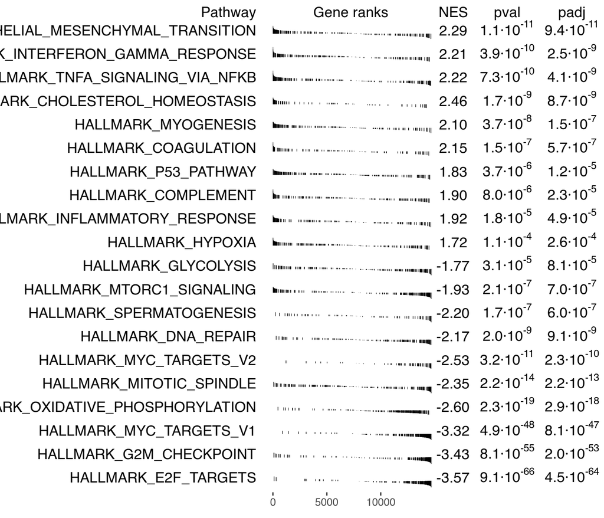

```r
topPathwaysUp <- fgseaRes[ES > 0][head(order(pval), n=10), pathway]
topPathwaysDown <- fgseaRes[ES < 0][head(order(pval), n=10), pathway]
topPathways <- c(topPathwaysUp, rev(topPathwaysDown))
plotGseaTable(geneSets[topPathways], geneRanks, fgseaRes,
              gseaParam=0.5)
```

We can visualize also as a simple barplot.

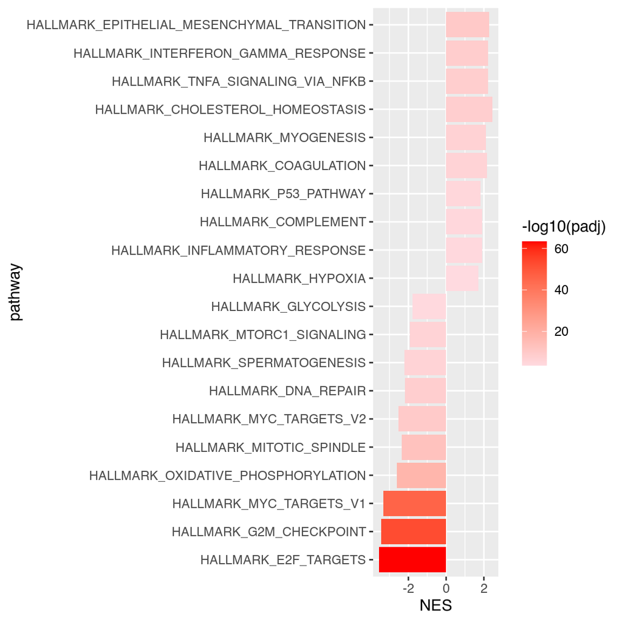

```r
df_gsea<- as.data.frame(fgseaRes)
df_gsea<- df_gsea[with(df_gsea, pathway %in% topPathways),]
df_gsea$pathway<- factor(df_gsea$pathway, levels=rev(topPathways)) # convert to factor and order the levels for plotting
ggplot(df_gsea, aes(x=pathway, y=NES, fill=-log10(padj)) )+
    geom_bar(stat="identity") +
    scale_fill_continuous(low="#ffdae0", high="red") +
    coord_flip()
```

We observe enrichment for TNFa signaling, Interferon gamma response and EMT pathways in CoV2 condition, while proliferation pathway enrichment in the mock.

### Enrichment plots

We can also visualize the enrichment of a specific pathway

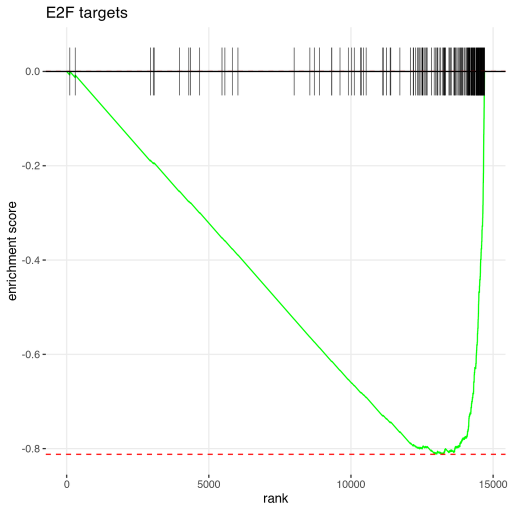

```r
plotEnrichment(geneSets[["HALLMARK_E2F_TARGETS"]],
               geneRanks) + labs(title="E2F targets")
```

We observe very strong enrichment for the E2F targets gene set in the mock.

### Visualize leading-edge genes

We can also visualize the leading-edge genes through a heatmap. Let’s first reload the counts and obtain the vst using DESeq2.

```r
raw_counts<- read.table("../data/GSE164073_Eye_count_matrix.tsv", header=T, row.names=1)
meta<- read.table("../data/GSE164073_Eye_count_meta.tsv", row.names=1)
meta$Condition<- factor(meta$Condition, levels=c("mock", "CoV2"))
meta_design<- model.matrix( ~ Condition, data=meta)
dds <- DESeqDataSetFromMatrix(countData = raw_counts,
                              colData = meta,
                              design= meta_design)
smallestGroupSize <- 3
keep <- rowSums(counts(dds) >= 10) >= smallestGroupSize
dds <- dds[keep,]
vsd <- vst(dds)
```

Now, we can visualize the leading edge genes for a particular pathway, in this case, the E2F targets.

```r
leadingEdges<- unlist(df_gsea[with(df_gsea, pathway == "HALLMARK_E2F_TARGETS"),"leadingEdge"])
head(leadingEdges)
```

```
[1] "RRM2"    "CDK1"    "HMMR"    "TOP2A"   "DLGAP5"  "RACGAP1"
```

[output not shown]

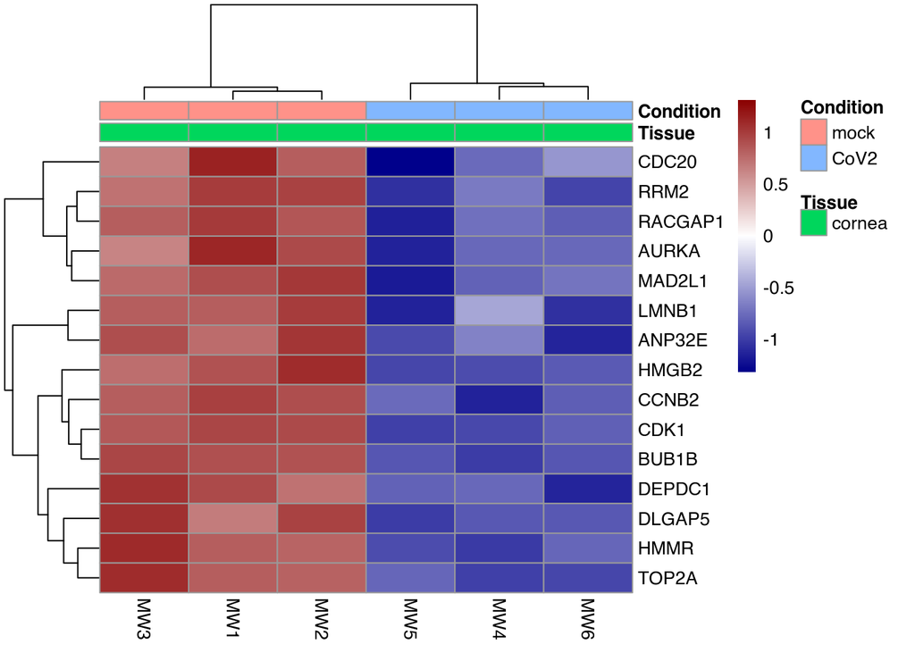

```r
# Let's filter for only cornea samples
meta_subset<- meta[with(meta, Tissue == "cornea"),]
colors <- colorRampPalette(c("darkblue","white","darkred"))(255)
pheatmap(assay(vsd[head(leadingEdges,15),rownames(meta_subset)]), annotation_col=meta_subset,col=colors, scale="row")
```

# Over representation analysis

**Note**: We will be running enrichR, which requires to establish a connection to the [Enrichr](https://maayanlab.cloud/Enrichr/) website.

```r
library(enrichR)
```

For running the next steps, please make sure that your connection is live:

```r
websiteLive <- getOption("enrichR.live")
websiteLive
```

```
[1] TRUE
```

You can check the databases available for GSEA:

```r
dbs <- listEnrichrDbs()
head(dbs)
```

|  | geneCoverage | genesPerTerm | libraryName | link | numTerms | appyter | categoryId |
| --- | --- | --- | --- | --- | --- | --- | --- |
| 1 | 13362 | 275 | Genome_Browser_PWMs | http://hgdownload.cse.ucsc.edu/goldenPath/hg18/database/ | 615 | ea115789fcbf12797fd692cec6df0ab4dbc79c6a | 1 |
| 2 | 27884 | 1284 | TRANSFAC_and_JASPAR_PWMs | http://jaspar.genereg.net/html/DOWNLOAD/ | 326 | 7d42eb43a64a4e3b20d721fc7148f685b53b6b30 | 1 |
| 3 | 6002 | 77 | Transcription_Factor_PPIs |  | 290 | 849f222220618e2599d925b6b51868cf1dab3763 | 1 |
| 4 | 47172 | 1370 | ChEA_2013 | http://amp.pharm.mssm.edu/lib/cheadownload.jsp | 353 | 7ebe772afb55b63b41b79dd8d06ea0fdd9fa2630 | 7 |
| 5 | 47107 | 509 | Drug_Perturbations_from_GEO_2014 | http://www.ncbi.nlm.nih.gov/geo/ | 701 | ad270a6876534b7cb063e004289dcd4d3164f342 | 7 |
| 6 | 21493 | 3713 | ENCODE_TF_ChIP-seq_2014 | http://genome.ucsc.edu/ENCODE/downloads.html | 498 | 497787ebc418d308045efb63b8586f10c526af51 | 7 |

Let’s do an enrichment analysis of genes upregulated in CoV2 using the Hallmark gene set.

```r
sig_genes<- rownames(res[with(res, abs(log2FoldChange > 1) & padj < 0.05 & !is.na(padj)),])
# Defining a background as the set of genes tested
background<- rownames(res)
enriched <- enrichr(genes=sig_genes, databases=c("MSigDB_Hallmark_2020"), background=background)
```

```
Uploading data to Speedrichr...
 - Your gene set... Done.
 - Your background... Done.
Getting enrichment results...
 - MSigDB_Hallmark_2020... Done.
Parsing results... Done.
```

```r
head(enriched[["MSigDB_Hallmark_2020"]])
```

|  | Term | Rank | P.value | Adjusted.P.value | Old.P.value | Old.Adjusted.P.value | Odds.Ratio | Combined.Score | Genes |
| --- | --- | --- | --- | --- | --- | --- | --- | --- | --- |
| 1 | TNF-alpha Signaling via NF-kB | 1 | 1.465945e-09 | 4.251240e-08 | 0 | 0 | 12.652793 | 257.36750 | CXCL6;IL6;TNFAIP6;ZC3H12A;TNFAIP2;G0S2;TNFAIP3;CXCL1;MSC;SOD2;ICAM1;RELB |
| 2 | Inflammatory Response | 2 | 2.141420e-07 | 3.105059e-06 | 0 | 0 | 12.025748 | 184.67491 | P2RX7;CXCL6;IL6;TNFAIP6;IRAK2;ITGB8;SCARF1;CX3CL1;ICAM1 |
| 3 | Complement | 3 | 5.871669e-07 | 5.675947e-06 | 0 | 0 | 10.583672 | 151.85407 | C3;DPP4;IL6;PCSK9;TNFAIP3;CXCL1;CFB;CTSS;C2 |
| 4 | Interferon Gamma Response | 4 | 1.359524e-06 | 9.856546e-06 | 0 | 0 | 9.508118 | 128.43923 | IL6;SOCS1;VCAM1;TNFAIP6;TNFAIP2;TNFAIP3;SOD2;CFB;ICAM1 |
| 5 | Allograft Rejection | 5 | 8.566858e-05 | 4.968777e-04 | 0 | 0 | 9.221327 | 86.35795 | IL6;SOCS1;IL16;CTSS;C2;ICAM1 |
| 6 | Epithelial Mesenchymal Transition | 6 | 2.678377e-04 | 1.294549e-03 | 0 | 0 | 6.100036 | 50.17359 | IL32;CXCL6;LRRC15;IL6;VCAM1;TNFAIP3;CXCL1 |

We can plot a barplot of the results

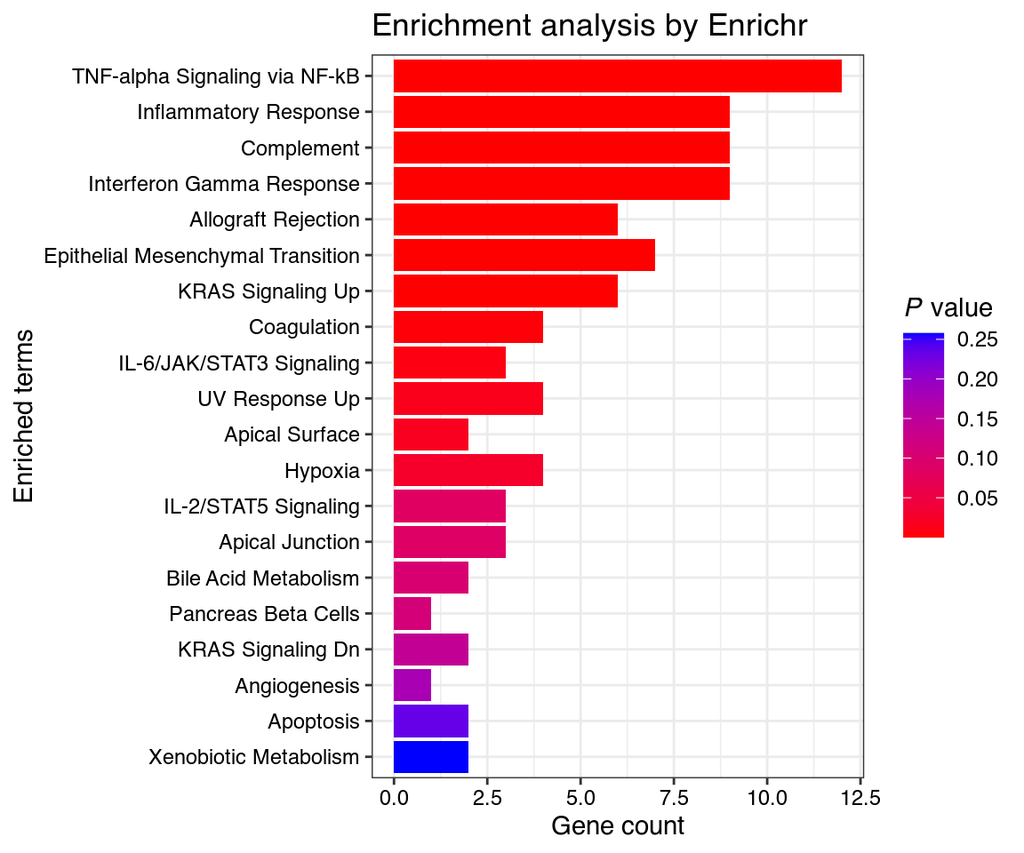

```r
plotEnrich(enriched[["MSigDB_Hallmark_2020"]], showTerms = 20, numChar = 40, y = "Count", orderBy = "P.value")
```

Similar as GSEA, we also observe enrichment for TNF alpha Signaling via NFKB and EMT pathways in the CoV2 condition.

# Exercises

- Run GSEA using a different gene set. You can find the KEGG legacy gene set in the data folder.

# Acknowledgements

This notebook used material adapted from the following sources:

- [fgsea vignette](https://bioconductor.org/packages/release/bioc/vignettes/fgsea/inst/doc/fgsea-tutorial.html)
- [enrichR vignette](https://cran.r-project.org/web/packages/enrichR/vignettes/enrichR.html)